# Participación política, confianza en instituciones y movimientos sociales explicando la satisfacción con la democracia en el Chile post estallido

Luciano Fica, Aline Bonnefoyn Nicolas Tobar, Francisco Arevalo

3/10/2021

# Abstract:

El objetivo de este trabajo es relacionar la satisfacción con la democracia con una serie de variables independientes tales como: afiliación con los movimientos sociales, participación política y confianza en las instituciones. El objetivo de este trabajo es relacionar la satisfacción de la democracia con una serie de variables claves. Ordenamos por interés y por evidencia aquellas que consideramos más apropiadas para comprender la democracia en el Chile contemporáneo: afiliación a los movimientos sociales, en primer lugar, confianza en las instituciones. La pregunta que guía esta investigación es la siguiente: ¿Cómo es la relación entre la satisfacción con la democracia en Chile, durante el 2019, y la participación política, la participación en movimientos sociales y la confianza en las instituciones, considerando éstos como predictores de la primera? A partir de la base de datos del Estudio Longitudinal Social de Chile del 2019, liberada a principios del año 2021, construimos una serie de índices que nos permiten profundizar en la relación estadística entre estas variables. Presentamos que la sociedad chilena está más conforme con su democracia en tanto confían más en las instituciones de una república, como también hemos descubierto una relación negativa entre la satisfacción con la democracia y una participación política y su filiación a movimientos sociales.

# Introducción

Chile vive, actualmente, una crisis social, económica, sanitaria y política, iniciadas, primero por el Estallido Social del 18 de octubre de 2019 (en adelante, 18O), y luego por la pandemia, que actualmente padecemos. Dentro de este escenario, está en curso un proceso constituyente, iniciado a raíz del 18O y que fue canalizado, institucionalmente, por el poder político. En este contexto, se hace necesario atender a los grados de satisfacción con la democracia que muestra la población chilena, por ser una de las categorías que más influyen en la legitimación de la misma (Cereceda-Marambio and Torres-Solís 2017; “Latinobarómetro Database” n.d.; Sanhueza, Sánchez, and Chinga 2015), y así poder distinguir cómo la confianza en las instituciones, la participación política y la filiación con algún movimiento social, impactaron en 2019 a la satisfacción democrática y, por tanto a la legitimidad de la democracia y el poder, con el fin de comprender de mejor forma los motivos que incitaron el Estallido del 18O. En función de este objetivo, explicaremos los principales conceptos a abordar en este estudio y los antecedentes de investigaciones anteriores respecto a la problemática que intentamos abordar. La legitimidad democrática (sinónimo de satisfacción democrática en este caso), se entiende como la validez que le da la ciudadanía al sistema político, democrático e institucional. Según Arroyo (1996), la legitimidad democrática es una expresión de los movimientos sociales. Por otro lado, López Hidalgo (2018) consideran la legitimidad como la aceptación social de los sistemas políticos. Uno de los indicadores para medir dicha legitimidad, es la satisfacción con la democracia, esta estima el desempeño del régimen democrático en el corto plazo Sanhueza, Sánchez, and Chinga (2015). Por otro lado, en Cereceda-Marambio and Torres-Solís (2017), se aborda nuestra variable dependiente considerando el quehacer político, crecimiento económico, los valores de la igualdad y la percepción de los derechos políticos civiles. Sanhueza, Sánchez, and Chinga (2015), por su parte, relacionan la satisfacción con la creencia en la democracia como el mejor sistema posible, una relación poco explorada. Gibert, Zmerli, and Newton (2008) llevaron a cabo un estudio que relaciona la satisfacción con la democracia con la confianza social, política y en las instituciones, así como la relación de estas tres variables con el “asociacionismo,” o sea, la participación en organizaciones y asociaciones voluntarias. Del Campo, Guemes, and RODRIGO (2017) estudiaron el impacto, en la satisfacción, del descontento con el Estado donde concluyeron que la confianza en el gobierno y la percepción de equidad social es lo que, principalmente, influye en la satisfacción democrática. La legitimidad del sistema político, expresada tanto a partir del apoyo a la democracia como por su nivel de satisfacción; puede estar influida por la participación ciudadana en política. En este ámbito, “IDH Bienestar Subjetivo El PNUD En Chile” (n.d.) señala que las personas que no asisten a votar son demócratas insatisfechos, además, la autora agrega que la legitimidad se mide en relación a las percepciones que tienen los ciudadanos según el apoyo al régimen.Sumado a esto, Chihu Amparán and López Gallegos (2007) agregan que el hecho de no sentirse representados en el principal cargo de gobierno los lleva a estar insatisfechos con el modo en que funciona el mismo. La definición de participación política, en lo referente al análisis, adhiere cualquier actividad, electoral, voluntaria o involuntaria, que influya en las decisiones, agentes, capacidades y movimientos dentro del espectro del campo político representativo. La confianza en las instituciones, es expresada como el grado de satisfacción que tiene la ciudadanía con el actuar de las instituciones. Según Gibert, Zmerli, and Newton (2008) la confianza en las instituciones es el apoyo “difuso” al sistema político, que se expresa en favor de la democracia o el apoyo a los resultados de un gobierno y autoridades específicas. Existen factores que influyen en la confianza de las instituciones, según Morales Quiroga (2008) un factor importante es el deterioro de la calidad de la democracia, ya que, determina la participación e identificación que tendrá la ciudadanía en las instituciones. Por otro lado, Quiroga (2020) aporta con el nivel de acercamiento con los partidos políticos, debido a que de éstos depende la identificación con el gobierno y así mismo su confianza en éste. De lo mencionado anteriormente, se podría apreciar una relación positiva entre confianza en las instituciones y satisfacción de la democracia, ya que, a mayor confianza en las instituciones, podría haber mayor satisfacción con la democracia y con el funcionamiento de los órganos que la componen y la posibilitan. La categoría filiación con movimiento social estima la cercanía y representación de las personas con el movimiento social. Éste se entenderá como una iniciativa colectiva y autorreflexiva, que se enfoca en las acciones expresivas de las y los integrantes de la colectividad, donde las identidades y el movimiento surgen debido a la acción colectiva conscientemente coordinada; sus miembros, de manera consciente, desarrollan ataques y defensas, aislando, diferenciando y marcando fronteras y se organizan creando lazos y redes solidarias (Chihu Amparán and López Gallegos 2007). Se ha decidido emplear esta variable, fuera de participación política, ya que los movimientos sociales no expresan, únicamente, conflictos políticos, sino que además expresan, fundamentalmente, conflictos sociales (Chihu Amparán and López Gallegos 2007). En el caso del 18O, se destacan tres tipos de conflictos: por una mejor calidad de vida, cambiar los modos de vida y búsqueda de mayor legitimidad y eficacia de las instituciones estatales (“IDH Bienestar Subjetivo El PNUD En Chile” n.d.).

# Objetivos e Hipótesis

En base a los antecedentes presentados y la problematización a resolver en el presente estudio, mencionaremos las hipótesis y objetivos que guiarán nuestro trabajo, orientado a mostrar la relación estadística entre los cuatro conceptos presentados anteriormente, revelando la naturaleza e intensidad presente en la correlación entre éstos y la influencia simultánea de las tres independientes en la satisfacción con la democracia.

## Objetivo general:

Correlacionar y analizar la Satisfacción con la democracia en relación con la Participación política, la Participación en movimientos sociales y la Confianza en instituciones, tanto de forma bivariada como multivariada, en base a los datos recogidos por el Estudio Longitudinal Social de Chile (“ELSOC – COES” n.d.).

## Objetivos específicos:

1. Relacionar la Satisfacción con la democracia con la Participación política en Chile.
2. Relacionar la Satisfacción con la democracia y la Participación en movimientos sociales en nuestro país.
3. Conocer la existencia de una relación entre la Satisfacción con la democracia de los/as chilenos/as y la Confianza en las instituciones.
4. Conocer y analizar la influencia simultánea de nuestros tres conceptos predictores -Participación política, Participación en movimiento social y Confianza en instituciones- en la Satisfacción con la democracia en Chile.

## Hipótesis derivadas de los antecedentes y objetivos específicos:

1. En primer lugar, de los antecedentes expuestos se desprende una posible asociación negativa entre la Satisfacción con la democracia y la Participación política, lo cual se expresa, principalmente, en los altos grados de abstención en elecciones y las masivas movilizaciones en Chile durante el 2019.
2. Por otro lado, consideramos que debiera existir una asociación negativa entre el Grado de filiación con algún movimiento social y la Satisfacción con la democracia, en base a que, con mayores conflictos y movilización, se refleja la insatisfacción con el sistema democrático vigente.
3. Por último, proponemos una relación positiva entre la Satisfacción con la democracia y la Confianza en instituciones, puesto que ambas expresan la cercanía y la aceptación del funcionamiento democrático e institucional.

# Metodología

## A) Base de datos

La base de datos utilizada corresponde al Estudio Longitudinal Social de Chile (ELSOC) del año 2019, elaborada por el Centro de Estudios de Conflicto y Cohesión Social (COES). La encuesta considera un total de 3417 personas encuestadas, y se levanta con el fin de “evaluar la manera cómo piensan, sienten y se comportan los chilenos en torno a un conjunto de temas referidos al conflicto y la cohesión social en Chile” (“ELSOC – COES” n.d.).

```r
dim(elsoc_2019)
```

```
## [1] 3417  374
```

## B) Variables

Las variables de interés extraídas para el análisis corresponden a: Satisfacción con la democracia, las relativas al módulo de Frecuencia de la participación política, al Grado de acuerdo con la filiación a determinado movimiento social y el Grado de confianza en las instituciones chilenas. A continuación se especifican las preguntas de cada variable y sus categorías de respuesta junto con su valor numérico:

### a. Variable dependiente:

Satisfacción con la democracia en Chile ● Categorías: nada satisfecho/a (1), poco satisfecho (2), algo satisfecho/a (3), bastante satisfecho/a (4), muy satisfecho/a (5), no sabe (-888), no responde (-999).

```r
find_var(data = elsoc_2019,"democracia") # Y
```

| col.nr | var.name | var.label |
| --- | --- | --- |
| 111 | c01 | Satisfaccion con la democracia en Chile |

```r
freqc01 <- freq(elsoc_2019$c01)
freqc01
```

```
## Frequencies
## elsoc_2019$c01
## Label: Satisfaccion con la democracia en Chile
## Type: Numeric
##
##               Freq   % Valid   % Valid Cum.   % Total   % Total Cum.
## ----------- ------ --------- -------------- --------- --------------
##        -999     20      0.59           0.59      0.59           0.59
##        -888     78      2.28           2.87      2.28           2.87
##           1   1786     52.27          55.14     52.27          55.14
##           2    916     26.81          81.94     26.81          81.94
##           3    463     13.55          95.49     13.55          95.49
##           4    109      3.19          98.68      3.19          98.68
##           5     45      1.32         100.00      1.32         100.00
##        <NA>      0                               0.00         100.00
##       Total   3417    100.00         100.00    100.00         100.00
```

### b. Variable independiente 1:

Índice de Frecuencia de participación política ● Dimensiones: firma carta o petición apoyando causa, asiste a marcha o manifestación pacífica, participa en huelga, usa redes sociales para opinar en temas públicos, participa en cacerolazos. ● Categorías: nunca (1), casi nunca (2), a veces (3), frecuentemente (4), muy frecuentemente (5), no sabe (-888), no responde (-999).

```r
find_var(data = elsoc_2019,"politica") # X
```

| col.nr | var.name | var.label |
| --- | --- | --- |
| 135 | c13 | Interes en la politica |
| 136 | c14_01 | Frecuencia: Habla de politica con familiares o amigos |
| 137 | c14_02 | Frecuencia: Se informa sobre politica en medios de comunicacion |
| 141 | c17 | Identificacion con coaliciones politicas |
| 142 | c17_otro | Identificacion con coaliciones politicas. Otra: especifique |
| 164 | c38 | Extension de corrupcion politica |
| 233 | c21_11 | Grado de acuerdo: Las politicas son injustas |

```r
freqc08_01 <- freq(elsoc_2019$c08_01)
freqc08_02 <- freq(elsoc_2019$c08_02)
freqc08_03 <- freq(elsoc_2019$c08_03)
freqc08_04 <- freq(elsoc_2019$c08_04)
freqc08_05 <- freq(elsoc_2019$c08_05)

freqc08_01
```

```
## Frequencies
## elsoc_2019$c08_01
## Label: Frecuencia: Firma carta o peticion apoyando causa
## Type: Numeric
##
##               Freq   % Valid   % Valid Cum.   % Total   % Total Cum.
## ----------- ------ --------- -------------- --------- --------------
##        -999      3     0.088          0.088     0.088          0.088
##           1   2617    76.588         76.675    76.588         76.675
##           2    339     9.921         86.596     9.921         86.596
##           3    341     9.980         96.576     9.980         96.576
##           4     96     2.809         99.385     2.809         99.385
##           5     21     0.615        100.000     0.615        100.000
##        <NA>      0                              0.000        100.000
##       Total   3417   100.000        100.000   100.000        100.000
```

```r
freqc08_02
```

```
## Frequencies
## elsoc_2019$c08_02
## Label: Frecuencia: Asiste a marcha o manifestacion pacifica
## Type: Numeric
##
##               Freq   % Valid   % Valid Cum.   % Total   % Total Cum.
## ----------- ------ --------- -------------- --------- --------------
##        -999      1     0.029          0.029     0.029          0.029
##        -888      1     0.029          0.059     0.029          0.059
##           1   2541    74.363         74.422    74.363         74.422
##           2    241     7.053         81.475     7.053         81.475
##           3    386    11.296         92.771    11.296         92.771
##           4    173     5.063         97.834     5.063         97.834
##           5     74     2.166        100.000     2.166        100.000
##        <NA>      0                              0.000        100.000
##       Total   3417   100.000        100.000   100.000        100.000
```

```r
freqc08_03
```

```
## Frequencies
## elsoc_2019$c08_03
## Label: Frecuencia: Participa en huelga
## Type: Numeric
##
##               Freq   % Valid   % Valid Cum.   % Total   % Total Cum.
## ----------- ------ --------- -------------- --------- --------------
##        -999      1     0.029          0.029     0.029          0.029
##        -888      2     0.059          0.088     0.059          0.088
##           1   3069    89.816         89.903    89.816         89.903
##           2    135     3.951         93.854     3.951         93.854
##           3    134     3.922         97.776     3.922         97.776
##           4     54     1.580         99.356     1.580         99.356
##           5     22     0.644        100.000     0.644        100.000
##        <NA>      0                              0.000        100.000
##       Total   3417   100.000        100.000   100.000        100.000
```

```r
freqc08_04
```

```
## Frequencies
## elsoc_2019$c08_04
## Label: Frecuencia: Usa redes sociales para opinar en temas publicos
## Type: Numeric
##
##               Freq   % Valid   % Valid Cum.   % Total   % Total Cum.
## ----------- ------ --------- -------------- --------- --------------
##           1   2130     62.34          62.34     62.34          62.34
##           2    250      7.32          69.65      7.32          69.65
##           3    509     14.90          84.55     14.90          84.55
##           4    321      9.39          93.94      9.39          93.94
##           5    207      6.06         100.00      6.06         100.00
##        <NA>      0                               0.00         100.00
##       Total   3417    100.00         100.00    100.00         100.00
```

```r
freqc08_05
```

```
## Frequencies
## elsoc_2019$c08_05
## Label: Frecuencia: Participa en cacerolazos
## Type: Numeric
##
##               Freq   % Valid   % Valid Cum.   % Total   % Total Cum.
## ----------- ------ --------- -------------- --------- --------------
##        -999      1     0.029          0.029     0.029          0.029
##        -888      1     0.029          0.059     0.029          0.059
##           1   2371    69.388         69.447    69.388         69.447
##           2    207     6.058         75.505     6.058         75.505
##           3    462    13.521         89.025    13.521         89.025
##           4    232     6.790         95.815     6.790         95.815
##           5    143     4.185        100.000     4.185        100.000
##        <NA>      0                              0.000        100.000
##       Total   3417   100.000        100.000   100.000        100.000
```

### c. Variable independiente 2:

Índice de filiación con movimiento social ● Dimensiones: siento un compromiso con este movimiento, me identifico con este movimiento, estoy de acuerdo con las acciones de este movimiento, pensar acerca del futuro de este movimiento me hace sentir esperanzado, las acciones y protestas de este movimiento pueden generar cambio social, los participantes me ven como un miembro más, la gente en general y quienes pertenecen al movimiento tienen posiciones similares. ● Categorías: totalmente en desacuerdo (1), en desacuerdo (2), ni de acuerdo ni en desacuerdo (3), de acuerdo (4), totalmente de acuerdo (5), no sabe (-888), no responde (-999).

```r
find_var(data = elsoc_2019,"movimiento") # X1
```

| col.nr | var.name | var.label |
| --- | --- | --- |
| 223 | c21_01 | Grado de acuerdo: Compromiso con el movimiento |
| 224 | c21_02 | Grado de acuerdo: Identificacion con el movimiento |
| 225 | c21_03 | Grado de acuerdo: Las acciones del movimiento |
| 226 | c21_04 | Grado de acuerdo: Esperanzado por el futuro del movimiento |
| 227 | c21_05 | Grado de acuerdo: Las acciones del movimiento generan cambio social |
| 229 | c21_07 | Grado de acuerdo: El movimiento esta alineado con mis valores |
| 230 | c21_08 | Grado de acuerdo: Posicion similar el movimiento y la gente |
| 231 | c21_09 | Grado de acuerdo: Posicion opuesta el movimiento y las autoridades |
| 234 | c22 | Frecuencia: Participacion del entrevistado en el movimiento social |
| 235 | c23 | Frecuencia: Participacion de familiares en el movimiento social |

[output cut: 1 more lines]

```r
freq (elsoc_2019)
```

[output not shown]

[output cut: 6632 more lines]

[output not shown]

```r
freq(elsoc_2019$c21_01)
```

```
## Frequencies
## elsoc_2019$c21_01
## Label: Grado de acuerdo: Compromiso con el movimiento
## Type: Numeric
##
##               Freq   % Valid   % Valid Cum.   % Total   % Total Cum.
## ----------- ------ --------- -------------- --------- --------------
##        -888      5      0.19           0.19      0.15           0.15
##           1     11      0.43           0.62      0.32           0.47
##           2     99      3.84           4.46      2.90           3.37
##           3    267     10.36          14.83      7.81          11.18
##           4   1672     64.91          79.74     48.93          60.11
##           5    522     20.26         100.00     15.28          75.39
##        <NA>    841                              24.61         100.00
##       Total   3417    100.00         100.00    100.00         100.00
```

```r
freq(elsoc_2019$c21_02)
```

```
## Frequencies
## elsoc_2019$c21_02
## Label: Grado de acuerdo: Identificacion con el movimiento
## Type: Numeric
##
##               Freq   % Valid   % Valid Cum.   % Total   % Total Cum.
## ----------- ------ --------- -------------- --------- --------------
##        -888      5      0.19           0.19      0.15           0.15
##           1     11      0.43           0.62      0.32           0.47
##           2     85      3.30           3.92      2.49           2.96
##           3    216      8.39          12.31      6.32           9.28
##           4   1718     66.69          79.00     50.28          59.56
##           5    541     21.00         100.00     15.83          75.39
##        <NA>    841                              24.61         100.00
##       Total   3417    100.00         100.00    100.00         100.00
```

```r
freq(elsoc_2019$c21_03)
```

```
## Frequencies
## elsoc_2019$c21_03
## Label: Grado de acuerdo: Las acciones del movimiento
## Type: Numeric
##
##               Freq   % Valid   % Valid Cum.   % Total   % Total Cum.
## ----------- ------ --------- -------------- --------- --------------
##        -999      1     0.039          0.039     0.029          0.029
##        -888     17     0.660          0.699     0.498          0.527
##           1     19     0.738          1.436     0.556          1.083
##           2    141     5.474          6.910     4.126          5.209
##           3    352    13.665         20.575    10.301         15.511
##           4   1584    61.491         82.065    46.356         61.867
##           5    462    17.935        100.000    13.521         75.388
##        <NA>    841                             24.612        100.000
##       Total   3417   100.000        100.000   100.000        100.000
```

```r
freq(elsoc_2019$c21_04)
```

```
## Frequencies
## elsoc_2019$c21_04
## Label: Grado de acuerdo: Esperanzado por el futuro del movimiento
## Type: Numeric
##
##               Freq   % Valid   % Valid Cum.   % Total   % Total Cum.
## ----------- ------ --------- -------------- --------- --------------
##        -888      9      0.35           0.35      0.26           0.26
##           1     13      0.50           0.85      0.38           0.64
##           2    116      4.50           5.36      3.39           4.04
##           3    206      8.00          13.35      6.03          10.07
##           4   1617     62.77          76.13     47.32          57.39
##           5    615     23.87         100.00     18.00          75.39
##        <NA>    841                              24.61         100.00
##       Total   3417    100.00         100.00    100.00         100.00
```

```r
freq(elsoc_2019$c21_05)
```

```
## Frequencies
## elsoc_2019$c21_05
## Label: Grado de acuerdo: Las acciones del movimiento generan cambio social
## Type: Numeric
##
##               Freq   % Valid   % Valid Cum.   % Total   % Total Cum.
## ----------- ------ --------- -------------- --------- --------------
##        -999      2     0.078          0.078     0.059          0.059
##        -888     16     0.621          0.699     0.468          0.527
##           1      9     0.349          1.048     0.263          0.790
##           2     82     3.183          4.231     2.400          3.190
##           3    160     6.211         10.443     4.682          7.872
##           4   1617    62.772         73.214    47.322         55.195
##           5    690    26.786        100.000    20.193         75.388
##        <NA>    841                             24.612        100.000
##       Total   3417   100.000        100.000   100.000        100.000
```

```r
freq(elsoc_2019$c21_06)
```

```
## Frequencies
## elsoc_2019$c21_06
## Label: Grado de acuerdo: Los participantes me ven como uno mas
## Type: Numeric
##
##               Freq   % Valid   % Valid Cum.   % Total   % Total Cum.
## ----------- ------ --------- -------------- --------- --------------
##        -999      8      0.31           0.31      0.23           0.23
##        -888    115      4.46           4.77      3.37           3.60
##           1    143      5.55          10.33      4.18           7.78
##           2    588     22.83          33.15     17.21          24.99
##           3    620     24.07          57.22     18.14          43.14
##           4    887     34.43          91.65     25.96          69.10
##           5    215      8.35         100.00      6.29          75.39
##        <NA>    841                              24.61         100.00
##       Total   3417    100.00         100.00    100.00         100.00
```

```r
freq(elsoc_2019$c21_07)
```

```
## Frequencies
## elsoc_2019$c21_07
## Label: Grado de acuerdo: El movimiento esta alineado con mis valores
## Type: Numeric
##
##               Freq   % Valid   % Valid Cum.   % Total   % Total Cum.
## ----------- ------ --------- -------------- --------- --------------
##        -999      1     0.039          0.039     0.029          0.029
##        -888     24     0.932          0.970     0.702          0.732
##           1     19     0.738          1.708     0.556          1.288
##           2    113     4.387          6.095     3.307          4.595
##           3    302    11.724         17.818     8.838         13.433
##           4   1648    63.975         81.793    48.229         61.662
##           5    469    18.207        100.000    13.725         75.388
##        <NA>    841                             24.612        100.000
##       Total   3417   100.000        100.000   100.000        100.000
```

```r
freq(elsoc_2019$c21_08)
```

```
## Frequencies
## elsoc_2019$c21_08
## Label: Grado de acuerdo: Posicion similar el movimiento y la gente
## Type: Numeric
##
##               Freq   % Valid   % Valid Cum.   % Total   % Total Cum.
## ----------- ------ --------- -------------- --------- --------------
##        -999      1     0.039          0.039     0.029          0.029
##        -888     67     2.601          2.640     1.961          1.990
##           1     16     0.621          3.261     0.468          2.458
##           2    139     5.396          8.657     4.068          6.526
##           3    265    10.287         18.944     7.755         14.282
##           4   1677    65.101         84.045    49.078         63.360
##           5    411    15.955        100.000    12.028         75.388
##        <NA>    841                             24.612        100.000
##       Total   3417   100.000        100.000   100.000        100.000
```

```r
freq(elsoc_2019$c21_09)
```

```
## Frequencies
## elsoc_2019$c21_09
## Label: Grado de acuerdo: Posicion opuesta el movimiento y las autoridades
## Type: Numeric
##
##               Freq   % Valid   % Valid Cum.   % Total   % Total Cum.
## ----------- ------ --------- -------------- --------- --------------
##        -999      1     0.039          0.039     0.029          0.029
##        -888     55     2.135          2.174     1.610          1.639
##           1     16     0.621          2.795     0.468          2.107
##           2    157     6.095          8.890     4.595          6.702
##           3    272    10.559         19.449     7.960         14.662
##           4   1500    58.230         77.679    43.898         58.560
##           5    575    22.321        100.000    16.828         75.388
##        <NA>    841                             24.612        100.000
##       Total   3417   100.000        100.000   100.000        100.000
```

```r
freq(elsoc_2019$c22)
```

```
## Frequencies
## elsoc_2019$c22
## Label: Frecuencia: Participacion del entrevistado en el movimiento social
## Type: Numeric
##
##               Freq   % Valid   % Valid Cum.   % Total   % Total Cum.
## ----------- ------ --------- -------------- --------- --------------
##        -999      1     0.039          0.039     0.029          0.029
##        -888      5     0.194          0.233     0.146          0.176
##           1   1381    53.610         53.843    40.416         40.591
##           2    320    12.422         66.266     9.365         49.956
##           3    545    21.157         87.422    15.950         65.906
##           4    230     8.929         96.351     6.731         72.637
##           5     94     3.649        100.000     2.751         75.388
##        <NA>    841                             24.612        100.000
##       Total   3417   100.000        100.000   100.000        100.000
```

```r
freq(elsoc_2019$c23)
```

```
## Frequencies
## elsoc_2019$c23
## Label: Frecuencia: Participacion de familiares en el movimiento social
## Type: Numeric
##
##               Freq   % Valid   % Valid Cum.   % Total   % Total Cum.
## ----------- ------ --------- -------------- --------- --------------
##        -999      2     0.078          0.078     0.059          0.059
##        -888     22     0.854          0.932     0.644          0.702
##           1   1287    49.961         50.893    37.665         38.367
##           2    301    11.685         62.578     8.809         47.176
##           3    585    22.710         85.287    17.120         64.296
##           4    286    11.102         96.390     8.370         72.666
##           5     93     3.610        100.000     2.722         75.388
##        <NA>    841                             24.612        100.000
##       Total   3417   100.000        100.000   100.000        100.000
```

```r
freq(elsoc_2019$c24)
```

```
## Frequencies
## elsoc_2019$c24
## Label: Frecuencia: Participacion de amigos en el movimiento social
## Type: Numeric
##
##               Freq   % Valid   % Valid Cum.   % Total   % Total Cum.
## ----------- ------ --------- -------------- --------- --------------
##        -999      6      0.23           0.23      0.18           0.18
##        -888     71      2.76           2.99      2.08           2.25
##           1    927     35.99          38.98     27.13          29.38
##           2    231      8.97          47.94      6.76          36.14
##           3    685     26.59          74.53     20.05          56.19
##           4    506     19.64          94.18     14.81          71.00
##           5    150      5.82         100.00      4.39          75.39
##        <NA>    841                              24.61         100.00
##       Total   3417    100.00         100.00    100.00         100.00
```

### d. Variable independiente 3:

Índice de grado de confianza en instituciones chilenas ● Dimensiones: el gobierno, los partidos políticos, Carabineros, sindicatos, Poder Judicial, empresas privadas, Congreso Nacional, Presidente, Fuerzas Armadas, Bomberos, medios de comunicación tradicionales, su municipalidad. ● Categorías: nada (1), poca (2), algo (3), bastante (4), mucha (5), no sabe (-888), no responde (-999).

```r
find_var(data = elsoc_2019,"confianza") # X2
```

| col.nr | var.name | var.label |
| --- | --- | --- |
| 62 | r16 | Grado de confianza en [PER-HAI-VEN] |
| 115 | c05_01 | Grado de confianza: El Gobierno |
| 116 | c05_02 | Grado de confianza: Los Partidos Politicos |
| 117 | c05_03 | Grado de confianza: Carabineros |
| 118 | c05_04 | Grado de confianza: Los Sindicatos |
| 119 | c05_05 | Grado de confianza: El Poder Judicial |
| 120 | c05_06 | Grado de confianza: Las Empresas Privadas |
| 121 | c05_07 | Grado de confianza: El Congreso Nacional |
| 122 | c05_08 | Grado de confianza: El Presidente/a de la Republica |
| 123 | c05_10 | Grado de confianza: Fuerzas Armadas |

[output cut: 3 more lines]

```r
freq(elsoc_2019$c05_01)
```

```
## Frequencies
## elsoc_2019$c05_01
## Label: Grado de confianza: El Gobierno
## Type: Numeric
##
##               Freq   % Valid   % Valid Cum.   % Total   % Total Cum.
## ----------- ------ --------- -------------- --------- --------------
##        -999      6      0.18           0.18      0.18           0.18
##        -888      6      0.18           0.35      0.18           0.35
##           1   2038     59.64          59.99     59.64          59.99
##           2    808     23.65          83.64     23.65          83.64
##           3    439     12.85          96.49     12.85          96.49
##           4     95      2.78          99.27      2.78          99.27
##           5     25      0.73         100.00      0.73         100.00
##        <NA>      0                               0.00         100.00
##       Total   3417    100.00         100.00    100.00         100.00
```

```r
freq(elsoc_2019$c05_02)
```

```
## Frequencies
## elsoc_2019$c05_02
## Label: Grado de confianza: Los Partidos Politicos
## Type: Numeric
##
##               Freq   % Valid   % Valid Cum.   % Total   % Total Cum.
## ----------- ------ --------- -------------- --------- --------------
##        -999     11     0.322          0.322     0.322          0.322
##        -888     12     0.351          0.673     0.351          0.673
##           1   2696    78.900         79.573    78.900         79.573
##           2    528    15.452         95.025    15.452         95.025
##           3    149     4.361         99.385     4.361         99.385
##           4     18     0.527         99.912     0.527         99.912
##           5      3     0.088        100.000     0.088        100.000
##        <NA>      0                              0.000        100.000
##       Total   3417   100.000        100.000   100.000        100.000
```

```r
freq(elsoc_2019$c05_03)
```

```
## Frequencies
## elsoc_2019$c05_03
## Label: Grado de confianza: Carabineros
## Type: Numeric
##
##               Freq   % Valid   % Valid Cum.   % Total   % Total Cum.
## ----------- ------ --------- -------------- --------- --------------
##        -999      2     0.059          0.059     0.059          0.059
##        -888      6     0.176          0.234     0.176          0.234
##           1   1106    32.368         32.602    32.368         32.602
##           2    781    22.856         55.458    22.856         55.458
##           3    801    23.442         78.900    23.442         78.900
##           4    499    14.603         93.503    14.603         93.503
##           5    222     6.497        100.000     6.497        100.000
##        <NA>      0                              0.000        100.000
##       Total   3417   100.000        100.000   100.000        100.000
```

```r
freq(elsoc_2019$c05_04)
```

```
## Frequencies
## elsoc_2019$c05_04
## Label: Grado de confianza: Los Sindicatos
## Type: Numeric
##
##               Freq   % Valid   % Valid Cum.   % Total   % Total Cum.
## ----------- ------ --------- -------------- --------- --------------
##        -999      9      0.26           0.26      0.26           0.26
##        -888    155      4.54           4.80      4.54           4.80
##           1   1354     39.63          44.42     39.63          44.42
##           2    735     21.51          65.94     21.51          65.94
##           3    821     24.03          89.96     24.03          89.96
##           4    279      8.17          98.13      8.17          98.13
##           5     64      1.87         100.00      1.87         100.00
##        <NA>      0                               0.00         100.00
##       Total   3417    100.00         100.00    100.00         100.00
```

```r
freq(elsoc_2019$c05_05)
```

```
## Frequencies
## elsoc_2019$c05_05
## Label: Grado de confianza: El Poder Judicial
## Type: Numeric
##
##               Freq   % Valid   % Valid Cum.   % Total   % Total Cum.
## ----------- ------ --------- -------------- --------- --------------
##        -999      7      0.20           0.20      0.20           0.20
##        -888     17      0.50           0.70      0.50           0.70
##           1   1641     48.02          48.73     48.02          48.73
##           2    901     26.37          75.10     26.37          75.10
##           3    675     19.75          94.85     19.75          94.85
##           4    149      4.36          99.21      4.36          99.21
##           5     27      0.79         100.00      0.79         100.00
##        <NA>      0                               0.00         100.00
##       Total   3417    100.00         100.00    100.00         100.00
```

```r
freq(elsoc_2019$c05_06)
```

```
## Frequencies
## elsoc_2019$c05_06
## Label: Grado de confianza: Las Empresas Privadas
## Type: Numeric
##
##               Freq   % Valid   % Valid Cum.   % Total   % Total Cum.
## ----------- ------ --------- -------------- --------- --------------
##        -999      7      0.20           0.20      0.20           0.20
##        -888     71      2.08           2.28      2.08           2.28
##           1   1487     43.52          45.80     43.52          45.80
##           2    931     27.25          73.05     27.25          73.05
##           3    713     20.87          93.91     20.87          93.91
##           4    181      5.30          99.21      5.30          99.21
##           5     27      0.79         100.00      0.79         100.00
##        <NA>      0                               0.00         100.00
##       Total   3417    100.00         100.00    100.00         100.00
```

```r
freq(elsoc_2019$c05_07)
```

```
## Frequencies
## elsoc_2019$c05_07
## Label: Grado de confianza: El Congreso Nacional
## Type: Numeric
##
##               Freq   % Valid   % Valid Cum.   % Total   % Total Cum.
## ----------- ------ --------- -------------- --------- --------------
##        -999      6      0.18           0.18      0.18           0.18
##        -888     29      0.85           1.02      0.85           1.02
##           1   2316     67.78          68.80     67.78          68.80
##           2    711     20.81          89.61     20.81          89.61
##           3    318      9.31          98.92      9.31          98.92
##           4     31      0.91          99.82      0.91          99.82
##           5      6      0.18         100.00      0.18         100.00
##        <NA>      0                               0.00         100.00
##       Total   3417    100.00         100.00    100.00         100.00
```

```r
freq(elsoc_2019$c05_08)
```

```
## Frequencies
## elsoc_2019$c05_08
## Label: Grado de confianza: El Presidente/a de la Republica
## Type: Numeric
##
##               Freq   % Valid   % Valid Cum.   % Total   % Total Cum.
## ----------- ------ --------- -------------- --------- --------------
##        -999      8      0.23           0.23      0.23           0.23
##        -888     10      0.29           0.53      0.29           0.53
##           1   2214     64.79          65.32     64.79          65.32
##           2    620     18.14          83.47     18.14          83.47
##           3    408     11.94          95.41     11.94          95.41
##           4    111      3.25          98.65      3.25          98.65
##           5     46      1.35         100.00      1.35         100.00
##        <NA>      0                               0.00         100.00
##       Total   3417    100.00         100.00    100.00         100.00
```

```r
freq(elsoc_2019$c05_10)
```

```
## Frequencies
## elsoc_2019$c05_10
## Label: Grado de confianza: Fuerzas Armadas
## Type: Numeric
##
##               Freq   % Valid   % Valid Cum.   % Total   % Total Cum.
## ----------- ------ --------- -------------- --------- --------------
##        -999      7      0.20           0.20      0.20           0.20
##        -888     18      0.53           0.73      0.53           0.73
##           1   1266     37.05          37.78     37.05          37.78
##           2    789     23.09          60.87     23.09          60.87
##           3    754     22.07          82.94     22.07          82.94
##           4    411     12.03          94.97     12.03          94.97
##           5    172      5.03         100.00      5.03         100.00
##        <NA>      0                               0.00         100.00
##       Total   3417    100.00         100.00    100.00         100.00
```

```r
freq(elsoc_2019$c05_11)
```

```
## Frequencies
## elsoc_2019$c05_11
## Label: Grado de confianza: Bomberos
## Type: Numeric
##
##               Freq   % Valid   % Valid Cum.   % Total   % Total Cum.
## ----------- ------ --------- -------------- --------- --------------
##        -999      1     0.029          0.029     0.029          0.029
##        -888      2     0.059          0.088     0.059          0.088
##           1     34     0.995          1.083     0.995          1.083
##           2     21     0.615          1.697     0.615          1.697
##           3    108     3.161          4.858     3.161          4.858
##           4    849    24.846         29.704    24.846         29.704
##           5   2402    70.296        100.000    70.296        100.000
##        <NA>      0                              0.000        100.000
##       Total   3417   100.000        100.000   100.000        100.000
```

```r
freq(elsoc_2019$c05_12)
```

```
## Frequencies
## elsoc_2019$c05_12
## Label: Grado de confianza: Medios de comunicacion tradicionales
## Type: Numeric
##
##               Freq   % Valid   % Valid Cum.   % Total   % Total Cum.
## ----------- ------ --------- -------------- --------- --------------
##        -999      2     0.059          0.059     0.059          0.059
##        -888      5     0.146          0.205     0.146          0.205
##           1   1037    30.348         30.553    30.348         30.553
##           2   1040    30.436         60.989    30.436         60.989
##           3    968    28.329         89.318    28.329         89.318
##           4    287     8.399         97.717     8.399         97.717
##           5     78     2.283        100.000     2.283        100.000
##        <NA>      0                              0.000        100.000
##       Total   3417   100.000        100.000   100.000        100.000
```

```r
freq(elsoc_2019$c05_13)
```

```
## Frequencies
## elsoc_2019$c05_13
## Label: Grado de confianza: Su municipalidad
## Type: Numeric
##
##               Freq   % Valid   % Valid Cum.   % Total   % Total Cum.
## ----------- ------ --------- -------------- --------- --------------
##        -999      3     0.088          0.088     0.088          0.088
##        -888     20     0.585          0.673     0.585          0.673
##           1    801    23.442         24.115    23.442         24.115
##           2    914    26.749         50.863    26.749         50.863
##           3   1059    30.992         81.855    30.992         81.855
##           4    491    14.369         96.225    14.369         96.225
##           5    129     3.775        100.000     3.775        100.000
##        <NA>      0                              0.000        100.000
##       Total   3417   100.000        100.000   100.000        100.000
```

```r
## Seleccion de variables
proc_elsoc <- elsoc_2019 %>% select(c01,
                                    c08_01,
                                    c08_02,
                                    c08_03,
                                    c08_04,
                                    c08_05,
                                    c21_01,
                                    c21_02,
                                    c21_03,
                                    c21_04,
                                    c21_05,
                                    c21_06,
                                    c21_07,
                                    c21_08,
                                    c05_01,
                                    c05_02,
                                    c05_03,
                                    c05_04,
                                    c05_05,
                                    c05_06,
                                    c05_07,
                                    c05_08,
                                    c05_10,
                                    c05_11,
                                    c05_12,
                                    c05_13)


## Obtener etiquetas de las variables
sjlabelled::get_label(proc_elsoc)
```

Con el fin de extraer la mayor información posible de las variables, se crearon los índices en base al promedio, agrupando las dimensiones de cada variable a considerar. Por otro lado, para no alterar los resultados numéricos del análisis, se eliminaron las categorías de respuesta correspondientes a “no sabe” y “no responde” -con valores de -888 y -999, respectivamente.

```r
## Recodificacion
proc_elsoc <- lapply(proc_elsoc[ ,1:26] ,
                     FUN = function(x) recode(x, "NaN = NA;-888=NA;-999=NA"))
proc_elsoc <- data.frame(proc_elsoc)

## Creación de índices en base al promedio
proc_elsoc <- proc_elsoc %>% rowwise() %>% mutate(media_politica = mean(c(c08_01, c08_02, c08_03, c08_04, c08_05), na.rm = T))
proc_elsoc <- proc_elsoc %>% rowwise() %>% mutate(media_movimiento = mean(c(c21_01, c21_02, c21_03, c21_04, c21_05, c21_06, c21_07, c21_08), na.rm = T))
proc_elsoc <- proc_elsoc %>% rowwise() %>% mutate(media_confianza = mean(c(c05_01, c05_02, c05_03, c05_04, c05_05, c05_06, c05_07, c05_08, c05_10, c05_11, c05_12, c05_13), na.rm = T))
```

```r
#Creacion nueva base de datos con solo las 4 variables (2 variables, 2 indices)
proc_elsoc2 <- proc_elsoc %>% select("c01", "media_politica", "media_movimiento", "media_confianza" )

proc_elsoc3 <- proc_elsoc2 %>% rename("SDemocracia" = c01,
                                      "FPPolitica" = media_politica,
                                      "MSociales" = media_movimiento,
                                      "CInstituciones" = media_confianza)

proc_elsoc3$SDemocracia <- set_label(x = proc_elsoc3$SDemocracia,label = "Satisfacción con la Democracia en Chile")
proc_elsoc3$FPPolitica <- set_label(x = proc_elsoc3$FPPolitica,label = "Frecuencia de Participación Política")
proc_elsoc3$MSociales <- set_label(x = proc_elsoc3$MSociales,label = "Afiliación a Movimiento Social")
proc_elsoc3$CInstituciones <- set_label(x = proc_elsoc3$CInstituciones,label = "Confianza en Instituciones")
```

A continuación, en la Tabla 1, se muestran los valores descriptivos de la variable Satisfacción con la democracia en Chile y de los índices: Frecuencia de participación política (media_politica), Grado de confianza en instituciones (media_confianza) y Grado de filiación con el movimiento social (media_movimiento).

|  | No | Variable | Label | Stats / Values | Freqs (% of Valid) | Graph | text.graph | Valid | Missing |
| --- | --- | --- | --- | --- | --- | --- | --- | --- | --- |
| 1 | 1 | SDemocracia\\\n[numeric] | Satisfacción con la Democracia en Chile | Mean (sd) : 1.7 (0.9)\\\nmin < med < max:\\\n1 < 1 < 5\\\nIQR (CV) : 1 (0.5) | 1 : 1369 (54.0%)\\\n2 : 728 (28.7%)\\\n3 : 333 (13.1%)\\\n4 : 75 ( 3.0%)\\\n5 : 30 ( 1.2%) |  | IIIIIIIIII \\ \nIIIII \\ \nII \\ \n \\ \n | 2535\\\n(100.0%) | 0\\\n(0.0%) |
| 2 | 2 | FPPolitica\\\n[numeric] | Frecuencia de Participación Política | Mean (sd) : 1.7 (0.8)\\\nmin < med < max:\\\n1 < 1.4 < 5\\\nIQR (CV) : 1 (0.5) | 24 distinct values |  | :\\\n:\\\n:\\\n: .\\\n: : : . . | 2535\\\n(100.0%) | 0\\\n(0.0%) |
| 3 | 3 | MSociales\\\n[numeric] | Afiliación a Movimiento Social | Mean (sd) : 3.9 (0.5)\\\nmin < med < max:\\\n1 < 3.9 < 5\\\nIQR (CV) : 0.5 (0.1) | 53 distinct values |  | \\ \\ \\ \\ \\ \\ \\ \\ \\ \\ :\\\n\\ \\ \\ \\ \\ \\ \\ \\ \\ \\ :\\\n\\ \\ \\ \\ \\ \\ \\ \\ \\ \\ :\\\n\\ \\ \\ \\ \\ \\ \\ \\ . : .\\\n\\ \\ \\ \\ \\ \\ . : : : : | 2535\\\n(100.0%) | 0\\\n(0.0%) |
| 4 | 4 | CInstituciones\\\n[numeric] | Confianza en Instituciones | Mean (sd) : 2.1 (0.6)\\\nmin < med < max:\\\n1 < 2.1 < 4.3\\\nIQR (CV) : 0.8 (0.3) | 76 distinct values |  | \\ \\ \\ \\ :\\\n\\ \\ \\ \\ : \\ \\ .\\\n\\ \\ . : . :\\\n\\ \\ : : : : :\\\n: : : : : : . . | 2535\\\n(100.0%) | 0\\\n(0.0%) |

## C) Método de análisis

Con el fin de conocer la intensidad de las relaciones entre nuestra variable dependiente: Satisfacción con la democracia, y nuestros predictores: Índices de Participación política, de Filiación con movimiento social y de Confianza en instituciones, emplearemos un modelo de regresión múltiple, el cual se encargará de estimar la fuerza y tipo de relaciones existentes a través del cálculo de coeficientes de regresión para cada una de las tres relaciones. Este tipo de modelo de análisis, permite controlar estadísticamente las variables y sus correlaciones, a través de coeficientes de regresión parciales, que se minimizan la influencia de las correlaciones entre predictores o variables independientes, con el fin de que no afecten en la estimación final del modelo.

# Analisis

## 2. Análisis de regresión Múltiple

A continuación, en la Tabla 2, se mostrarán los resultados y se hará un análisis bivariado de la relación estadística entre la variable dependiente: Satisfacción con la democracia y las variables independientes/predictores: Frecuencia de participación política, Grado de filiación con movimiento social y Grado de confianza en las instituciones.

```r
rs.1 <-lm(SDemocracia ~ FPPolitica, data=proc_elsoc4)
rs.2 <-lm(SDemocracia ~  MSociales, data=proc_elsoc4)
rs.3 <-lm(SDemocracia ~  CInstituciones, data=proc_elsoc4)
r.mult <- lm(SDemocracia ~ FPPolitica + MSociales + CInstituciones , data = proc_elsoc4)
```

Modelo 1

Modelo 2

Modelo 3

Módelo Múltiple

Predictores

ß

ß

ß

ß

(Intercept)

1.92 ***

2.35 ***

0.30 ***

0.62 ***

Frecuencia de  
Participación Política

-0.14 ***

-0.04 *

Afiliación a Movimiento  
Social

-0.17 ***

-0.05

Confianza en  
Instituciones

0.65 ***

0.63 ***

Observations

2535

2535

2535

2535

R<sup>2</sup> / R<sup>2</sup> adjusted

0.016 / 0.016

0.010 / 0.010

0.170 / 0.169

0.173 / 0.172

- p<0.05 ** p<0.01 *** p<0.001

La frecuencia de participación política dio como coeficiente de regresión un -0.14 en el modelo 1 -modelo de regresión simple que vincula la variable dependiente solo con la variable FPPolitica-, y baja a -0.04 en el modelo múltiple -modelo que agrupa todas las variables independientes o predictores, e indica el grado de correlación entre éstas y la variable dependiente. Estas cifras muestran que por cada punto adicional en FPPolitica, en el modelo múltiple, se presenta una disminución de 0.04 -la cual es baja si nos fijamos en el valor de R2 = 0.016 ~ 0.01- en la satisfacción con la democracia. Esto significa que ambas variables se correlacionan de forma negativa, indicando que a mayor frecuencia de participación política, menor satisfacción con la democracia. Este valor se interpreta con un 95% de confianza, ya que la probabilidad de error es de p<0.05.

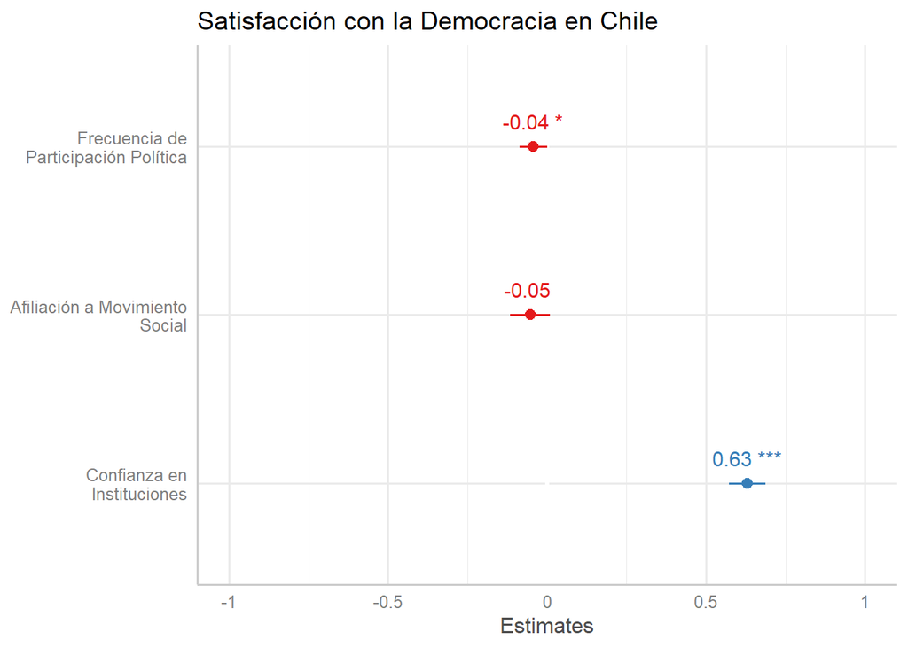

```r
graf.control <- plot_model(r.mult, show.values = TRUE)+ theme_sjplot()
```

## 3. Resultados, Conclusiones y Limitaciones

A partir del modelo de regresión múltiple y del análisis expuesto anteriormente tenemos, en base a nuestras hipótesis planteadas al principio del informe, que:

# Referencias Bibliográficas

Arroyo, Juan Carlos Velasco. 1996. “Tomarse En Serio La Desobediencia Civil: Un Criterio de Legitimidad Democrágica.” *Revista Internacional de Filosofía Política*, no. 7: 159–84. https://dialnet.unirioja.es/servlet/articulo?codigo=2704751.

Cereceda-Marambio, Karina, and Amanda Torres-Solís. 2017. “Satisfacción Con La Democracia En Chile: De Lo Normativo a Lo Valorativo.” *Revista de Sociología*, no. 32 (December): 32–49. https://doi.org/10.5354/0719-529X.2017.47884.

Chihu Amparán, Aquiles, and Alejandro López Gallegos. 2007. “La Construcción de La Identidad Colectiva En Alberto Melucci.” *Polis* 3 (1): 125–59. http://www.scielo.org.mx/scielo.php?script=sci_abstract&pid=S1870-23332007000100006&lng=es&nrm=iso&tlng=es.

Del Campo, Esther, Cecilia Guemes, and Ludolfo RODRIGO. 2017. “«I Can’t Get No Satisfaction». Servicios públicos, Democracia y Clases Medias En América Latina.” *América Latina Hoy* 77 (December): 161. https://doi.org/10.14201/alh201777161187.

“ELSOC – COES.” n.d. Accessed October 5, 2021. https://coes.cl/encuesta-panel/.

Gibert, José Ramón Montero, Sonja Zmerli, and Ken Newton. 2008. “Confianza Social, Confianza Política y Satisfacción Con La Democracia.” *REIS: Revista Española de Investigaciones Sociológicas*, no. 122: 11–54. https://dialnet.unirioja.es/servlet/articulo?codigo=2571847.

“IDH Bienestar Subjetivo El PNUD En Chile.” n.d. *UNDP*. Accessed October 5, 2021. https://www.cl.undp.org/content/chile/es/home/library/human_development/publication_3.html.

“Latinobarómetro Database.” n.d. Accessed October 5, 2021. https://www.latinobarometro.org/lat.jsp.

López Hidalgo, Pablo Sebastián. 2018. *Reflexiones Acerca de La Legitimidad Democrática de La Justicia Constitucional En Ecuador*. Quito: Universidad Andina Simón Bolívar, Sede Ecuador; Corporación de Estudios y Publicaciones. http://repositorio.uasb.edu.ec/handle/10644/7105.

Morales Quiroga, Mauricio. 2008. “Evaluando La Confianza Institucional En Chile: Una Mirada Desde Los Resultados LAPOP.” *Revista de Ciencia Política (Santiago)* 28 (2): 161–86. https://doi.org/10.4067/S0718-090X2008000200007.

Quiroga, Mauricio Morales. 2020. “Estallido Social En Chile 2019: Participación, Representación, Confianza Institucional y Escándalos públicos.” *Análisis Político* 33 (98): 3–25. https://doi.org/10.15446/anpol.v33n98.89407.

Sanhueza, Cristian Eduardo Alister, Constanza Cea Sánchez, and Alex Guerrero Chinga. 2015. “Democracia En Latinoamérica, ¿Qué Factores Influyen En La Satisfacción y Apoyo a La Democracia?” *Fronteras - ISSN 0719-4285* 2 (1): 85–113. http://publicacionescienciassociales.ufro.cl/index.php/fronteras/article/view/445.